# 3. Time Series Decomposition.RMD

Russ Conte

10/3/2021

Adjusting the historical data can often lead to a simpler time series. Here, we deal with four kinds of adjustments: calendar adjustments, population adjustments, inflation adjustments and mathematical transformations. The purpose of these adjustments and transformations is to simplify the patterns in the historical data by removing known sources of variation, or by making the pattern more consistent across the whole data set. Simpler patterns are usually easier to model and lead to more accurate forecasts.

Calendar adjustments

Some of the variation seen in seasonal data may be due to simple calendar effects. In such cases, it is usually much easier to remove the variation before doing any further analysis.

For example, if you are studying the total monthly sales in a retail store, there will be variation between the months simply because of the different numbers of trading days in each month, in addition to the seasonal variation across the year. It is easy to remove this variation by computing average sales per trading day in each month, rather than total sales in the month. Then we effectively remove the calendar variation.

Population adjustments

Any data that are affected by population changes can be adjusted to give per-capita data. That is, consider the data per person (or per thousand people, or per million people) rather than the total. For example, if you are studying the number of hospital beds in a particular region over time, the results are much easier to interpret if you remove the effects of population changes by considering the number of beds per thousand people. Then you can see whether there have been real increases in the number of beds, or whether the increases are due entirely to population increases. It is possible for the total number of beds to increase, but the number of beds per thousand people to decrease. This occurs when the population is increasing faster than the number of hospital beds. **For most data that are affected by population changes, it is best to use per-capita data rather than the totals.**

```r
library(tidyverse)
library(fpp3)
```

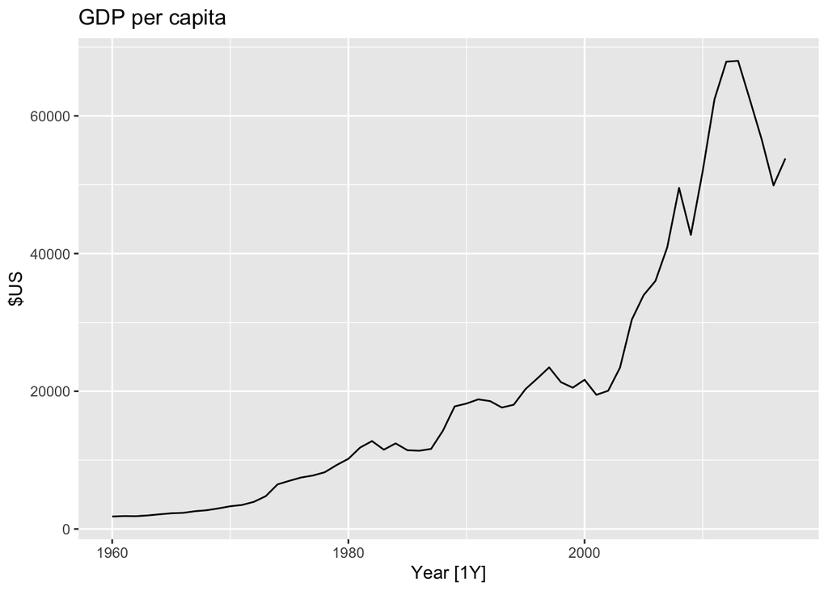

```r
global_economy %>%
  filter(Country == "Australia") %>%
  autoplot(GDP/Population) +
  labs(title = "GDP per capita", y = "$US")
```

Inflation adjustments

**Data which are affected by the value of money are best adjusted before modelling.** For example, the average cost of a new house will have increased over the last few decades due to inflation. A $200,000 house this year is not the same as a $200,000 house twenty years ago. For this reason, **financial time series are usually adjusted so that all values are stated in dollar values from a particular year.** For example, the house price data may be stated in year 2000 dollars.

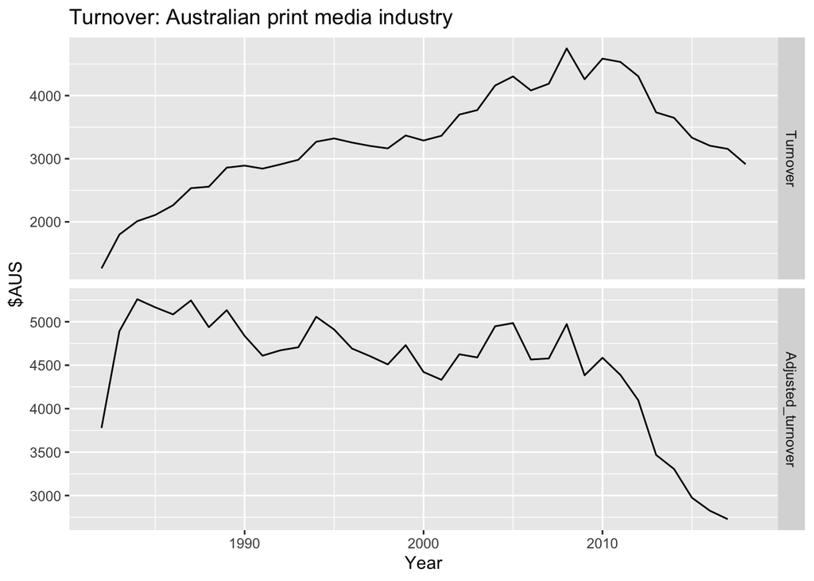

```r
print_retail <- aus_retail %>%
  filter(Industry == "Newspaper and book retailing") %>%
  group_by(Industry) %>%
  index_by(Year = year(Month)) %>%
  summarise(Turnover = sum(Turnover))

aus_economy <- global_economy %>%
  filter(Code == "AUS")

print_retail %>%
  left_join(aus_economy, by = "Year") %>%
  mutate(Adjusted_turnover = Turnover / CPI * 100) %>%
  pivot_longer(c(Turnover, Adjusted_turnover), values_to = "Turnover") %>%
  mutate(name = factor(name, levels = c("Turnover", "Adjusted_turnover"))) %>%
  ggplot(aes(x = Year, y = Turnover)) +
  geom_line() +
  facet_grid(name~., scales = "free_y") +
  labs(title = "Turnover: Australian print media industry", y = "$AUS")
```

By adjusting for inflation using the CPI, we can see that Australia’s newspaper and book retailing industry has been in decline much longer than the original data suggests. The adjusted turnover is in 2010 Australian dollars, as CPI is 100 in 2010 in this data set.

Mathematical transformations

If the data shows variation that increases or decreases with the level of the series, then a transformation can be useful. For example, a logarithmic transformation is often useful.

Sometimes other transformations are also used (although they are not so interpretable). For example, square roots and cube roots can be used. These are called power transformations because they can be written in the form
$$w_t = y^p_t$$

A useful family of transformations, that includes both logarithms and power transformations, is the family of **Box-Cox transformations** (Box & Cox, 1964), which depend on the parameter λ and are defined as follows:

$$w_t = \begin{cases}
log(y_t) \textrm{ if } \lambda = 0;\\
(sign(y_t)|y_t|^\lambda -1)/\lambda \textrm{ otherwise}
\end{cases}$$

A good value of λ is one which makes the size of the seasonal variation about the same across the whole series, as that makes the forecasting model simpler. In this case, λ = 0.10 works quite well, although any value of λ between 0.0 and 0.2 would give similar results.

The `guerrero` feature (Guerrero, 1993) can be used to choose a value of lambda for you. In this case it chooses λ = 0.12.

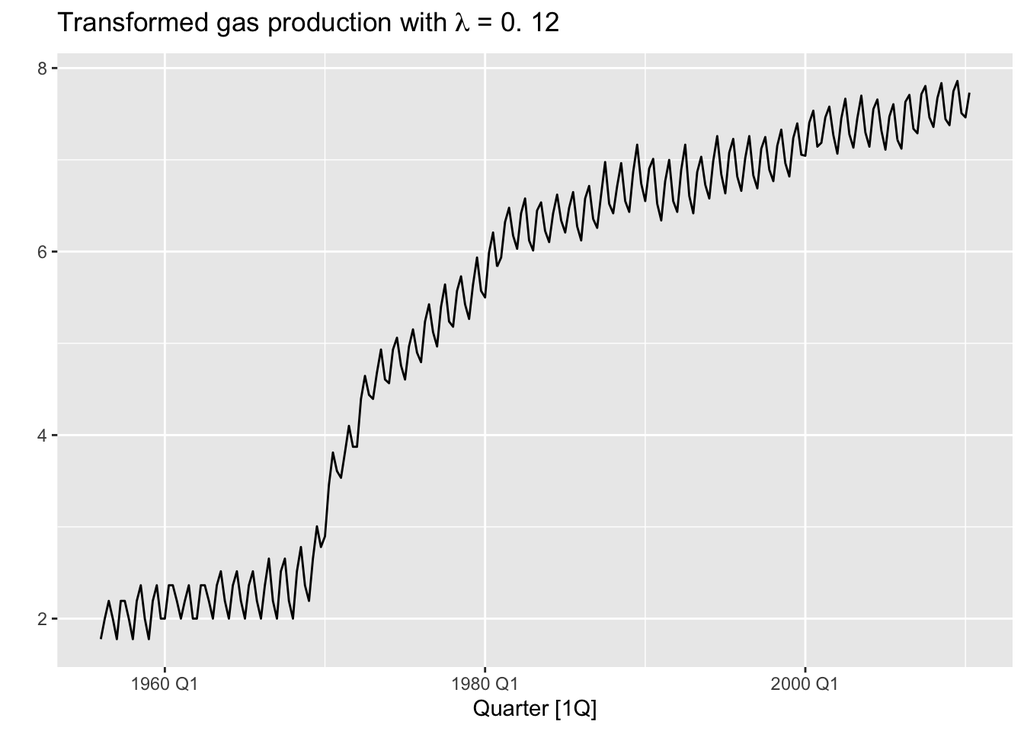

```r
lambda <- aus_production %>%
  features(Gas, features = guerrero) %>%
  pull(lambda_guerrero)

aus_production %>%
  autoplot(box_cox(Gas, lambda)) +
  labs(y = "",
       title = latex2exp::TeX(paste0("Transformed gas production with $\\lambda$ = ",
                                    round(lambda, 2))))
```

## 3.2 Time series components

If we assume an additive decomposition, then we can write:

$$y_t = S_t + T_t + R_t$$
where
$$y_t \textrm{ is the data, } S_t \textrm{ is the seasonal component, } T_t\textrm{ is the trend-cycle component, } and R_t \textrm{ is the remainder component at a time t.}$$
Alternatively, a multiplicative decomposition would be written as:

$$y_t = S_t \times T_t \times R_t$$

## Employment in the US Retail Sector

We will decompose the number of persons employed in retail as shown in Figure 3.5. The data shows the total monthly number of persons in thousands employed in the retail sector across the US since 1990.

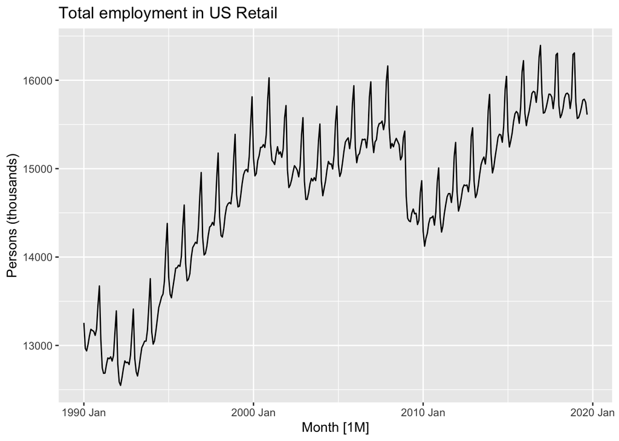

```r
us_retail_employment <- us_employment %>%
  filter(year(Month) >= 1990, Title == "Retail Trade") %>%
  select(-Series_ID)
autoplot(us_retail_employment, Employed) +
  labs(y = "Persons (thousands)",
       title = "Total employment in US Retail")
```

To illustrate the ideas, we will use the STL decomposition method, which is discussed in Section 3.6.

```r
dcmp <- us_retail_employment %>%
  model(stl = STL(Employed))
components(dcmp)
```

```
## # A dable: 357 x 7 [1M]
## # Key:     .model [1]
## # :        Employed = trend + season_year + remainder
##    .model    Month Employed  trend season_year remainder season_adjust
##    <chr>     <mth>    <dbl>  <dbl>       <dbl>     <dbl>         <dbl>
##  1 stl    1990 Jan   13256. 13288.      -33.0      0.836        13289.
##  2 stl    1990 Feb   12966. 13269.     -258.     -44.6          13224.
##  3 stl    1990 Mar   12938. 13250.     -290.     -22.1          13228.
##  4 stl    1990 Apr   13012. 13231.     -220.       1.05         13232.
##  5 stl    1990 May   13108. 13211.     -114.      11.3          13223.
##  6 stl    1990 Jun   13183. 13192.      -24.3     15.5          13207.
##  7 stl    1990 Jul   13170. 13172.      -23.2     21.6          13193.
##  8 stl    1990 Aug   13160. 13151.       -9.52    17.8          13169.
##  9 stl    1990 Sep   13113. 13131.      -39.5     22.0          13153.
## 10 stl    1990 Oct   13185. 13110.       61.6     13.2          13124.
## # … with 347 more rows
```

The output above shows the components of an STL decomposition. The original data is shown (as `Employed`), followed by the estimated components. This output forms a “dable” or decomposition table. The header to the table shows that the `Employed` series has been decomposed additively.

The `trend` column containing the trend-cycle
$$T_t \textrm{ follows the overall movement of the series, ignoring any seasonality and random fluctuations, as shown in Figure 3.6.}$$

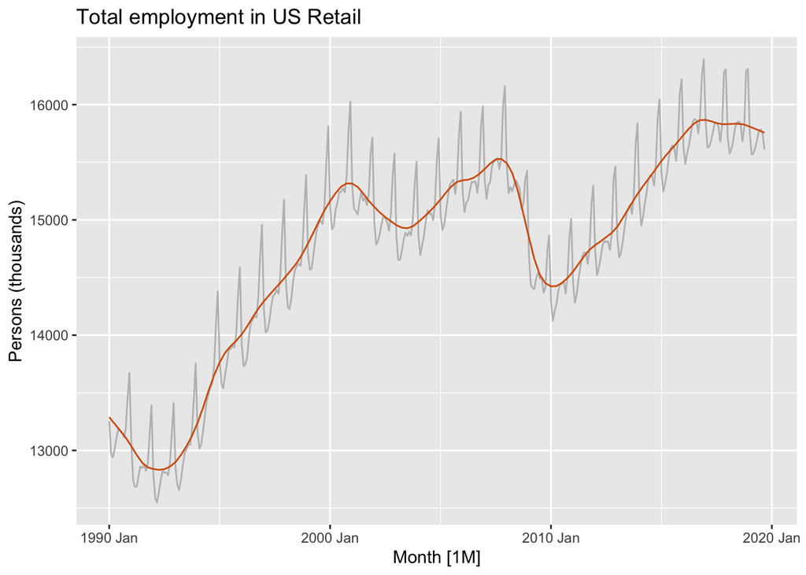

```r
components(dcmp) %>%
  as_tsibble() %>%
  autoplot(Employed, colour = "gray") +
  geom_line(aes(y = trend), colour = "#D55E00") +
  labs(y = "Persons (thousands)",
       title = "Total employment in US Retail")
```

We can plot all of the components in a single figure using `autoplot()`, as shown in Figure 3.7.

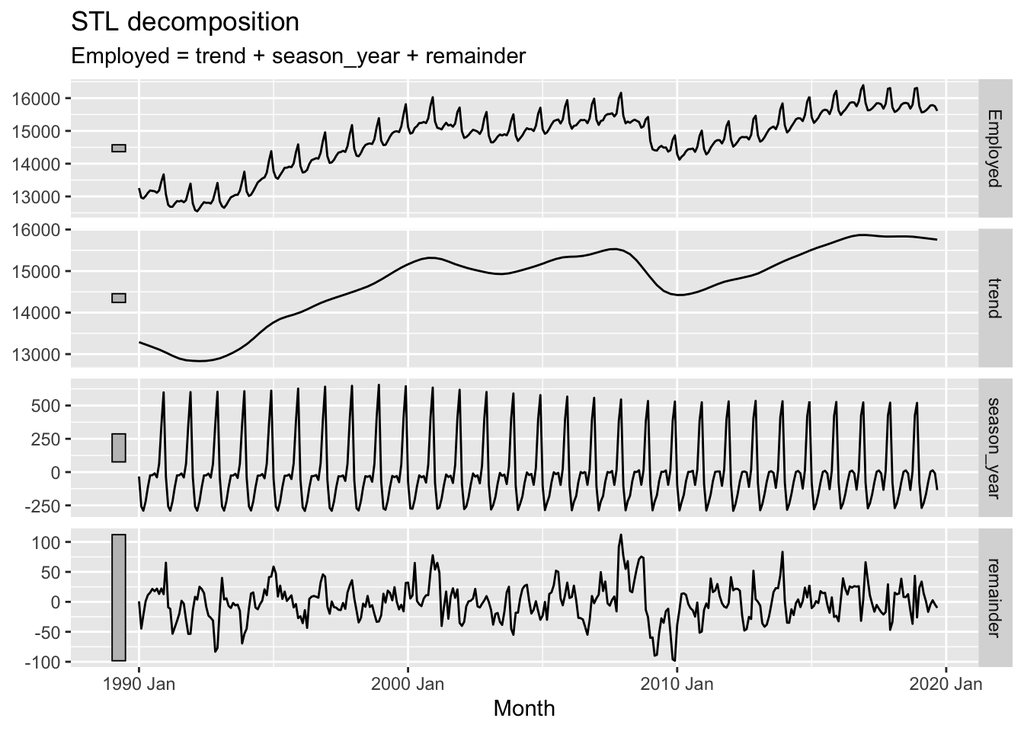

```r
components(dcmp) %>% autoplot()
```

## Seasonally adjusted data

If the seasonal component is removed from the original data, the resulting values are the “seasonally adjusted” data. For an additive decomposition, the seasonally adjusted data are given by
$$y_t - S_t$$
and for multiplicative data, the seasonally adjusted values are obtained using
$$y_t/S_t$$

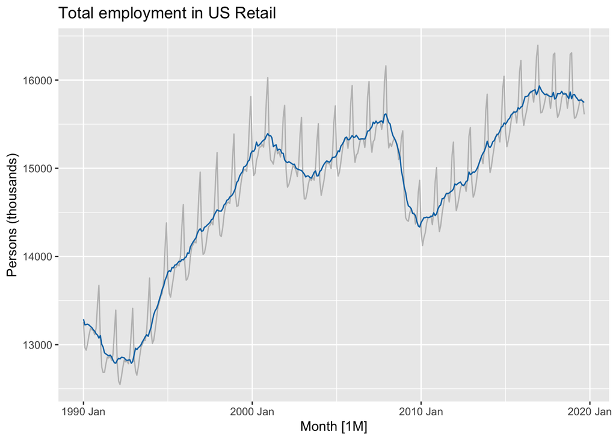

```r
components(dcmp) %>%
  as_tsibble() %>%
  autoplot(Employed, colour = "gray") +
  geom_line(aes(y = season_adjust), colour = "#0072B2") +
  labs(y = "Persons (thousands)",
       title = "Total employment in US Retail")
```

If the variation due to seasonality is not of primary interest, the seasonally adjusted series can be useful. For example, monthly unemployment data are usually seasonally adjusted in order to highlight variation due to the underlying state of the economy rather than the seasonal variation. An increase in unemployment due to school leavers seeking work is seasonal variation, while an increase in unemployment due to an economic recession is non-seasonal. Most economic analysts who study unemployment data are more interested in the non-seasonal variation. Consequently, employment data (and many other economic series) are usually seasonally adjusted.

## 3.3 Moving Averages

The first step in a classical decomposition is to use a moving average method to estimate the trend-cycle, so we begin by discussing moving averages.

Moving average smoothing

The moving average of order `m` can be written as:

$$\hat{T_t} = \frac{1}{m}\sum_{j = -k}^{k}y_{t+j}$$

where m = 2k+1

Observations that are nearby in time are also likely to be close in value. Therefore, the average eliminates some of the randomness in the data, leaving a smooth trend-cycle component. We call this an m**-MA**, meaning a moving average of order m.

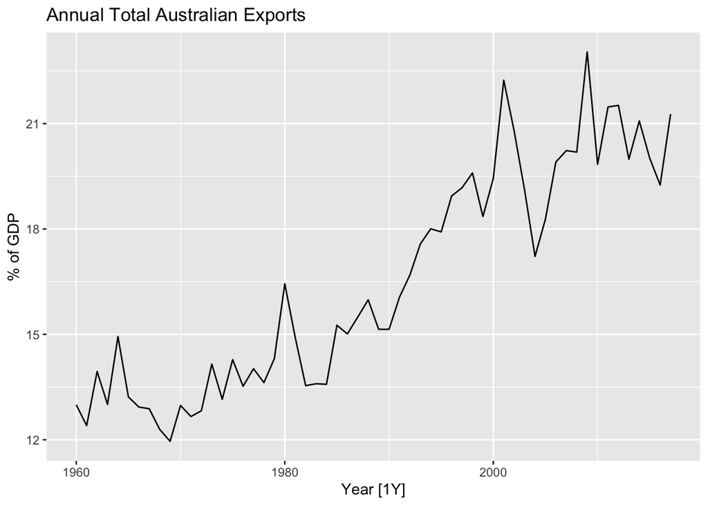

```r
global_economy %>%
  filter(Country == "Australia") %>%
  autoplot(Exports) +
  labs(y = "% of GDP", title = "Annual Total Australian Exports")
```

```r
global_economy %>%
  filter(Country == "Australia") %>%
  select(Year, Exports)
```

```
## # A tsibble: 58 x 2 [1Y]
##     Year Exports
##    <dbl>   <dbl>
##  1  1960    13.0
##  2  1961    12.4
##  3  1962    13.9
##  4  1963    13.0
##  5  1964    14.9
##  6  1965    13.2
##  7  1966    12.9
##  8  1967    12.9
##  9  1968    12.3
## 10  1969    12.0
## # … with 48 more rows
```

In the last column of this table, a moving average of order 5 is shown, providing an estimate of the trend-cycle. The first value in this column is the average of the first five observations, 1960–1964; the second value in the 5-MA column is the average of the values for 1961–1965; and so on. This is easily computed using `slide_dbl()` from the `slider` package which applies a function to “sliding” time windows. In this case, we use the mean() function with a window of size 5.

```r
aus_exports <- global_economy %>%
   filter(Country == "Australia") %>%
   mutate(
     `5-MA` = slider::slide_dbl(Exports, mean,
                  .before = 2,  .after = 2, .complete = TRUE))
aus_exports
```

```
## # A tsibble: 58 x 10 [1Y]
## # Key:       Country [1]
##    Country   Code   Year      GDP Growth   CPI Imports Exports Population `5-MA`
##    <fct>     <fct> <dbl>    <dbl>  <dbl> <dbl>   <dbl>   <dbl>      <dbl>  <dbl>
##  1 Australia AUS    1960  1.86e10  NA     7.96    14.1    13.0   10276477   NA
##  2 Australia AUS    1961  1.96e10   2.49  8.14    15.0    12.4   10483000   NA
##  3 Australia AUS    1962  1.99e10   1.30  8.12    12.6    13.9   10742000   13.5
##  4 Australia AUS    1963  2.15e10   6.21  8.17    13.8    13.0   10950000   13.5
##  5 Australia AUS    1964  2.38e10   6.98  8.40    13.8    14.9   11167000   13.6
##  6 Australia AUS    1965  2.59e10   5.98  8.69    15.3    13.2   11388000   13.4
##  7 Australia AUS    1966  2.73e10   2.38  8.98    15.1    12.9   11651000   13.3
##  8 Australia AUS    1967  3.04e10   6.30  9.29    13.9    12.9   11799000   12.7
##  9 Australia AUS    1968  3.27e10   5.10  9.52    14.5    12.3   12009000   12.6
## 10 Australia AUS    1969  3.66e10   7.04  9.83    13.3    12.0   12263000   12.6
## # … with 48 more rows
```

To see what the trend-cycle estimate looks like, we plot it along with the original data in Figure 3.10.

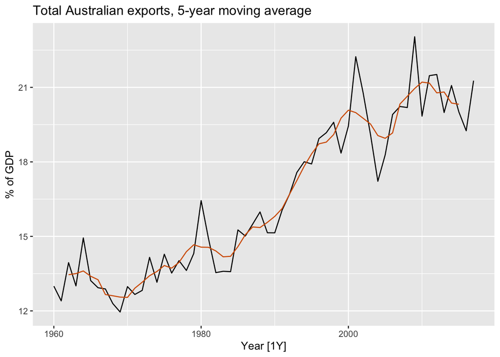

```r
aus_exports %>%
  autoplot(Exports) +
  geom_line(aes(y = `5-MA`), colour = "#D55E00") +
  labs(y = "% of GDP",
       title = "Total Australian exports, 5-year moving average") +
  guides(colour = guide_legend(title = "series"))
```

Notice that the trend-cycle (in orange) is smoother than the original data and captures the main movement of the time series without all of the minor fluctuations. The order of the moving average determines the smoothness of the trend-cycle estimate. In general, a larger order means a smoother curve.

## Moving averages of moving averages

It is possible to apply a moving average to a moving average. One reason for doing this is to make an even-order moving average symmetric.

For example, we might take a moving average of order 4, and then apply another moving average of order 2 to the results. In the following table, this has been done for the first few years of the Australian quarterly beer production data.

```r
beer <- aus_production %>%
  filter(year(Quarter) >= 1992) %>%
  select(Quarter, Beer)

beer_ma <-  beer %>%
  mutate(
    `4-MA` = slider::slide_dbl(Beer, mean,
                                .before = 1, .after = 2, .complete = TRUE),
    `2x4-MA` = slider::slide_dbl(`4-MA`, mean,
                                  .before = 1, .after = 0, .complete = TRUE)
  )
beer_ma
```

```
## # A tsibble: 74 x 4 [1Q]
##    Quarter  Beer `4-MA` `2x4-MA`
##      <qtr> <dbl>  <dbl>    <dbl>
##  1 1992 Q1   443    NA       NA
##  2 1992 Q2   410   451.      NA
##  3 1992 Q3   420   449.     450
##  4 1992 Q4   532   452.     450.
##  5 1993 Q1   433   449      450.
##  6 1993 Q2   421   444      446.
##  7 1993 Q3   410   448      446
##  8 1993 Q4   512   438      443
##  9 1994 Q1   449   441.     440.
## 10 1994 Q2   381   446      444.
## # … with 64 more rows
```

The notation “ 2×4-MA” in the last column means a 4-MA followed by a 2-MA. The values in the last column are obtained by taking a moving average of order 2 of the values in the previous column. For example, the first two values in the 4-MA column are 451.25=(443+410+420+532)/4 and 448.75=(410+420+532+433)/4. The first value in the 2x4-MA column is the average of these two: 450.00=(451.25+448.75)/2.

When a 2-MA follows a moving average of an even order (such as 4), it is called a “centred moving average of order 4.” This is because the results are now symmetric. To see that this is the case, we can write the 2×4-MA as follows:

## Estimating the trend = cycle with seasonal data

The most common use of centered moving averages is for estimating the trend = cycl from seasonal data. Consider the 2x4-MA:

When applied to quarterly data, each quarter of the year is given equal weight as the first and last terms apply to the same quarter in consecutive years. Consequently, the seasonal variation will be averaged out and the resulting values of
$$\hat{T_t}$$
will have little or no seasonal variation remaining. A similar effect wuld be obtained using a 2xz8-MA or 2x12-MA to quarterly data.

## Example: Employment in the US Retail Sector

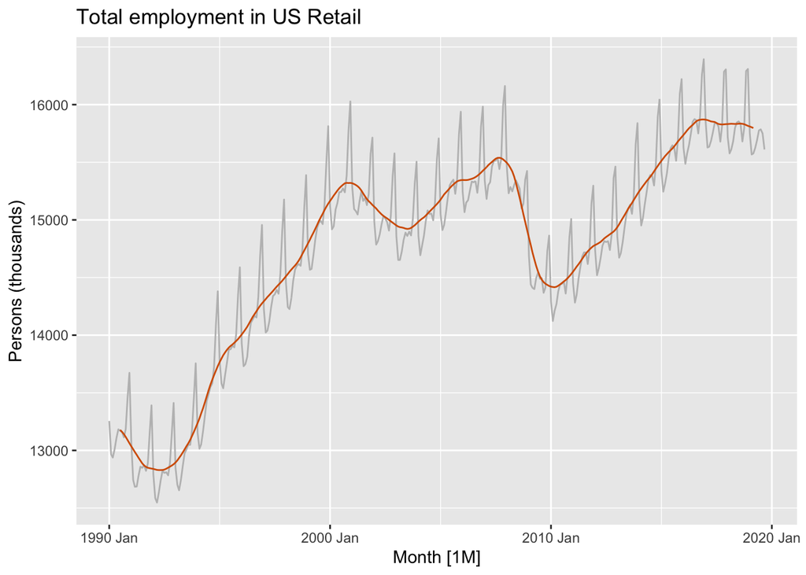

```r
us_retail_employment_ma <- us_retail_employment %>%
  mutate(
    `12-MA` = slider::slide_dbl(Employed, mean,
                                .before = 5, .after = 6, .complete = TRUE),
    `2x12-MA` = slider::slide_dbl(`12-MA`, mean,
                                  .before = 1, .after = 0, .complete = TRUE)
  )

us_retail_employment_ma %>%
  autoplot(Employed, colour = "gray") +
  geom_line(aes(y = `2x12-MA`), colour = "#D55E00") +
  labs(y = "Persons (thousands)",
       title = "Total employment in US Retail")
```

## 3.4 Classical decomposition

### Additive decomposition

Step 1:

$$\textrm{If m is an even number, compute the trend-cycle component }\hat{T_t} \textrm{ using a 2 x MA. If m is an odd number, compute the trebd-cycle component}\hat{T_t} \textrm{using an m=MA.}$$

Step 2:
Calculate the detrended series:
$$y_t - \hat{T_t}$$

Step 3:
To estimate the seasonal component for each season, simply average the detrended values for that season. For example, with monthly data, the seasonal component for March is the average of all the detrended March values in the data. These seasonal component values are then adjusted to ensure that they add to zero. The seasonal component is obtained by stringing together these monthly values, and then replicating the sequence for each year of data. This gives
$$\hat{S_t}$$

Step 4:

The remainder component is calculated by subracting the estimated seasonal and trend-cycle components:
$$\hat{R_t} = \hat{y_t} - \hat{T_t} - \hat{S_t}$$

Figure 3.13 shows a classical decomposition of the total retail employment series across the US.

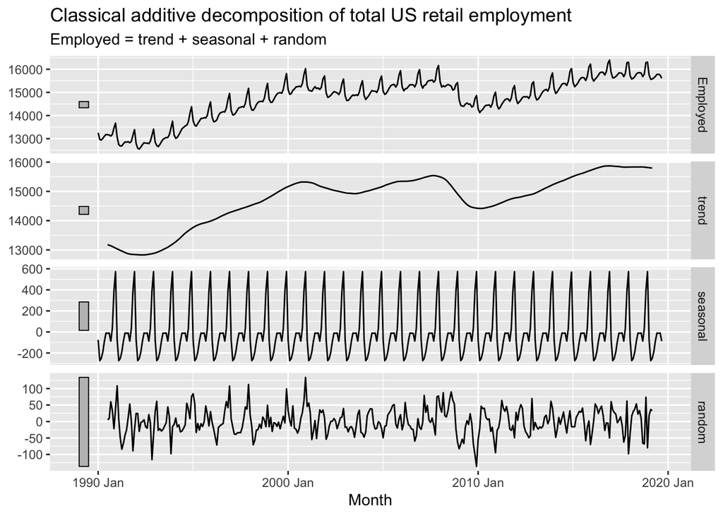

```r
us_retail_employment %>%
  model(
    classical_decomposition(Employed, type = "additive")
  ) %>%
  components() %>%
  autoplot() +
  labs(title = "Classical additive decomposition of total US retail employment")
```

### Comments of classical decomposition

While classical decomposition is still widely used, it is not recommended, as there are now several much better methods. Some of the problems with classical decomposition are summarised below.

• The estimate of the trend-cycle is unavailable for the first few and last few observations. For example, if m=12, there is no trend-cycle estimate for the first six or the last six observations. Consequently, there is also no estimate of the remainder component for the same time periods. • The trend-cycle estimate tends to over-smooth rapid rises and falls in the data. • Classical decomposition methods assume that the seasonal component repeats from year to year. For many series, this is a reasonable assumption, but for some longer series it is not. For example, electricity demand patterns have changed over time as air conditioning has become more widespread. In many locations, the seasonal usage pattern from several decades ago had its maximum demand in winter (due to heating), while the current seasonal pattern has its maximum demand in summer (due to air conditioning). Classical decomposition methods are unable to capture these seasonal changes over time. • Occasionally, the values of the time series in a small number of periods may be particularly unusual. For example, the monthly air passenger traffic may be affected by an industrial dispute, making the traffic during the dispute different from usual. The classical method is not robust to these kinds of unusual values.

## Methods used by official statistics agencies

### X-11 method

The X-11 method originated in the US Census Bureau and was further developed by Statistics Canada. It is based on classical decomposition, but includes many extra steps and features in order to overcome the drawbacks of classical decomposition that were discussed in the previous section. In particular, trend-cycle estimates are available for all observations including the end points, and the seasonal component is allowed to vary slowly over time. X-11 also handles trading day variation, holiday effects and the effects of known predictors.

```r
# x11_dcmp <- us_retail_employment %>%
#   model(x11 = X_13ARIMA_SEATS(Employed ~ x11())) %>%
#   components()
library(seasonal)
```

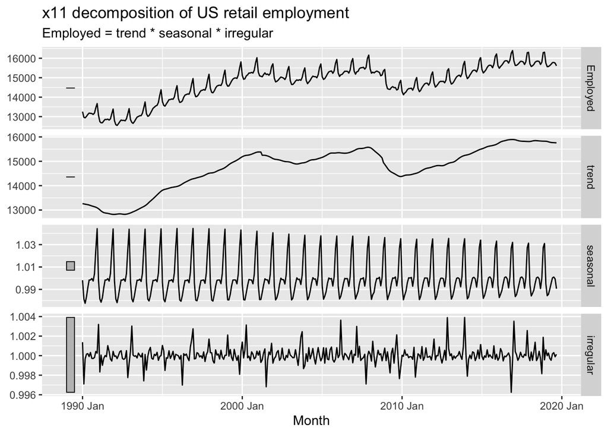

```r
x11_dcmp <- us_retail_employment %>%
  model(x11 = X_13ARIMA_SEATS(Employed ~ x11())) %>%
  components()

autoplot(x11_dcmp) +
           labs(title = "x11 decomposition of US retail employment")
```

Compare this decomposition with the STL decomposition shown in Figure 3.7 and the classical decomposition shown in Figure 3.13. The X-11 trend-cycle has captured the sudden fall in the data due to the 2007–2008 global financial crisis better than either of the other two methods (where the effect of the crisis has leaked into the remainder component). Also, the unusual observation in 1996 is now more clearly seen in the X-11 remainder component.

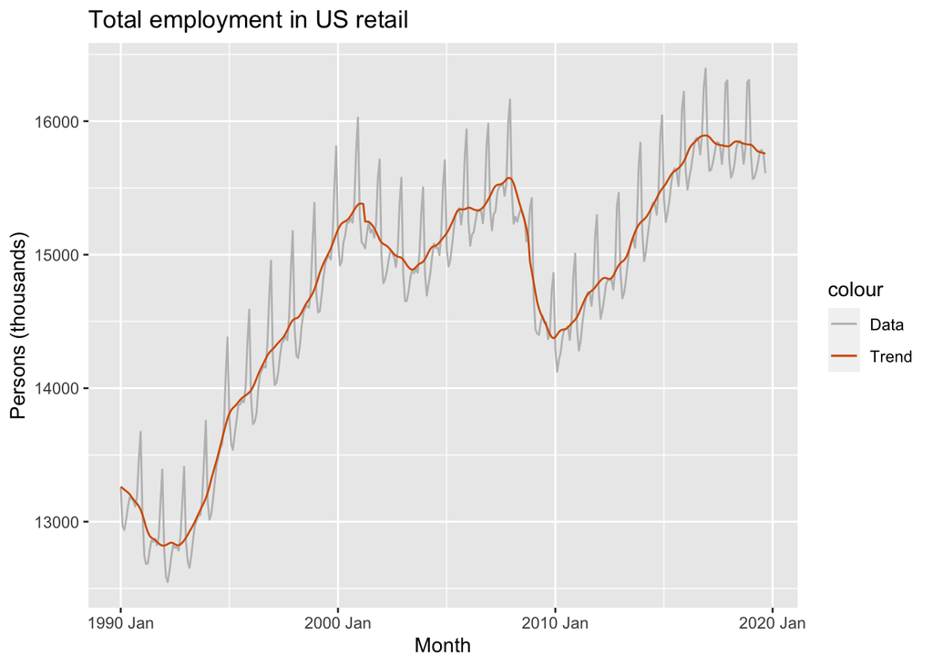

```r
x11_dcmp %>%
  ggplot(aes(x = Month)) +
  geom_line(aes(y = Employed, colour = "Data")) +
  geom_line(aes(y = trend, colour = "Trend")) +
  labs(y = "Persons (thousands)", title = "Total employment in US retail") +

  scale_color_manual(
    values = c("gray", "#0072B2", "#D55E00"),
    breaks = c("Data", "Seasonally Adjusted", "Trend")
  )
```

t can be useful to use seasonal plots and seasonal sub-series plots of the seasonal component, to help us visualise the variation in the seasonal component over time. Figure 3.16 shows a seasonal sub-series plot of the seasonal component from Figure 3.14. In this case, there are only small changes over time.

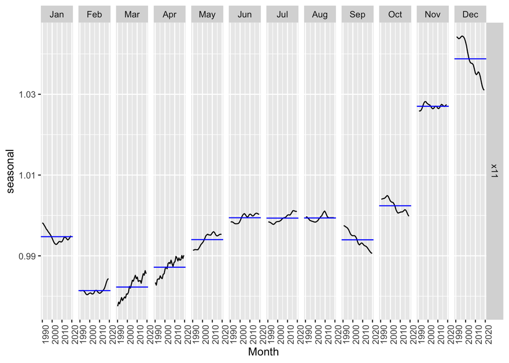

```r
x11_dcmp %>%
  gg_subseries(seasonal)
```

## SEATS method

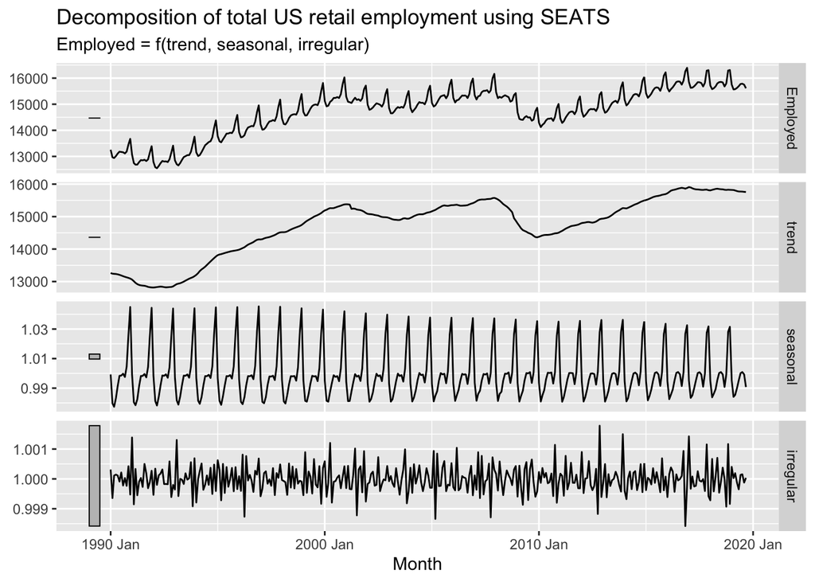

```r
seats_dcmp <- us_retail_employment %>%
  model(seats = X_13ARIMA_SEATS(Employed ~ seats())) %>%
  components()
autoplot(seats_dcmp) +
  labs(title = "Decomposition of total US retail employment using SEATS")
```

## STL decomposition

STL is a versatile and robust method for decomposing time series. STL is an acronym for “Seasonal and Trend decomposition using Loess,” while loess is a method for estimating nonlinear relationships. The STL method was developed by R. B. Cleveland et al. (1990).

The best way to begin learning how to use STL is to see some examples and experiment with the settings. Figure 3.7 showed an example of an STL decomposition applied to the total US retail employment series. Figure 3.18 shows an alternative STL decomposition where the trend-cycle is more flexible, the seasonal pattern is fixed, and the robust option has been used.

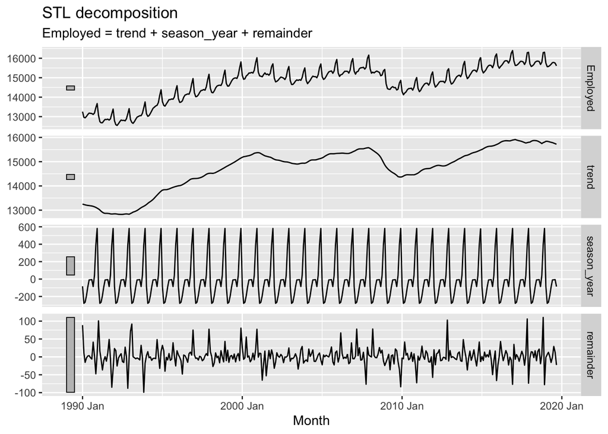

```r
us_retail_employment %>%
  model(
    STL(Employed ~ trend(window = 7) +
          season(window = "periodic"),
        robust = TRUE)) %>%
  components() %>%
  autoplot()
```

The two main parameters to be chosen when using STL are the trend-cycle window `trend(window = ?)` and the seasonal `window season(window = ?)`. These control how rapidly the trend-cycle and seasonal components can change. Smaller values allow for more rapid changes. Both trend and seasonal windows should be odd numbers; trend window is the number of consecutive observations to be used when estimating the trend-cycle; season window is the number of consecutive years to be used in estimating each value in the seasonal component. Setting the seasonal window to be infinite is equivalent to forcing the seasonal component to be periodic `season(window='periodic'`) (i.e., identical across years). This was the case in Figure 3.18.

Conclusion of chapter 3! :)